# Zaman Serileri Analizi

Hafta #1 - Uygulama

Dr. Ömer Kara

Thursday, February 12, 2026

**Önemli Notlar**

- Yanında **Değiştirmeyin** ibaresi bulunan hiçbir kodu ve/veya satırı değiştirmeyin.
- Yazılardakı ve kodlardaki açıklamaları dikkatlice okuyun.
- Kodların sırasını **mümkün olduğunca** değiştirmeyin. Aksi taktirde hata ile karşılaşabilirsiniz.
- Paketler bölümünde, gerekli [R paketlerini](https://cran.r-project.org/web/packages/available_packages_by_name.html) [`okara`](https://github.com/omerkara/okara) paketindeki `Load.Install` fonksiyonunu kullanarak indirin ve yükleyin.
- Seed bölümünde, istediğiniz sayıyı kullanabilirsiniz. Rassal olarak seçilen değerler, eğer varsa, seçtiğiniz sayıya göre değişecektir.
- R hakkında daha fazla bilgi için, benim yazdığım [R mini BootCamp](https://akademiekonometri.bitbucket.io/R_mini_BootCamp/R_mini_BootCamp.html) adlı İngilizce kaynaktan faydalanabilirsiniz.

# 1 Hazırlık

## 1.1 Paketler

- [R paketlerini](https://cran.r-project.org/web/packages/available_packages_by_name.html) [`okara`](https://github.com/omerkara/okara) paketindeki `Load.Install` fonksiyonunu kullanarak indirin ve/veya yükleyin.

```r
# Devtools ve okara paketlerinin yüklenmesi.
if("devtools" %in% rownames(utils::installed.packages()) == FALSE) {suppressWarnings(suppressMessages(install.packages("devtools")))}
suppressWarnings(suppressMessages(library("devtools"))) ## devtools paketi, okara paketinin yüklenmesi için gereklidir.
if("okara" %in% rownames(utils::installed.packages()) == FALSE) {suppressWarnings(suppressMessages(devtools::install_github("omerkara/okara", force = FALSE)))}
suppressWarnings(suppressMessages(library("okara"))) ## okara paketi.

# Gerekli paketlerin yüklenmesi.
Load.Install(c("rstudioapi", "readxl", "plyr", "dplyr", "tidyr", "stringr", "stringi", "Hmisc", "reshape2", "scales", "lubridate", "ggplot2", "xtable", "DT", "latex2exp", "forecast", "WDI", "fpp2", "fpp3", "datasets", "quantmod", "FinYang/tsdl", "ggseas", "slider", "ecm", "wooldridge"))
```

## 1.2 Seed

- Aşağıdaki `R kodu` bölümünde istediğiniz sayıyı girebilirsiniz.

```r
set.seed(1234)
```

## 1.3 Çalışma Klasörü

- Aşağıdaki `R kodu`, R çalışma klasörünü (yani working directory) sadece bu dosya için, bu dosyanın bilgisayarınızda bulunan lokasyonunda belirliyor.
  - `getwd()` fonksiyonunu kullanarak mevcut çalışma klasörünün hangi lokasyonda belirlendiğine bakabilirsiniz.

```r
# Değiştirmeyin.
main.path <- dirname(rstudioapi::getActiveDocumentContext()$path) ## Bu kod otomatik olarak kaynak dosyasının, yani üzerinde çalıştığınız dosyanın, bilgisayarınızda hangi lokasyonda olduğunu buluyor.
setwd(paste0(main.path)) ## Yeni çalışma klasörü (yani working directory) bu kaynak dosyasının lokasyonunda belirleniyor.
```

# 2 Veri Yükleme

- Bu bölümde zaman serileri verisinin farklı kaynaklardan yüklenmesi gösterilecektir.

## 2.1 World Bank Verisi

- [World Bank](https://data.worldbank.org/)’ten direkt olarak `WDI` R paketini kullanarak veri indirip yüklemeye çalışalım.
- World Bank’ten veri indirip yüklemek için temel olarak 2 fonksiyonu kullanacağız: `WDIsearch` ve `WDI`.
  - `WDIsearch` fonksiyonu ile indirip yüklemek istediğimiz veriyi belirleyebiliriz.
  - `WDI` fonksiyonu ile belirlediğimiz veriyi indirip yükleyebiliriz.
- Örnek olması açısından “Türkiye için Nominal Gayri Safi Yurtiçi Hasıla” verisini TL cinsinden indirip yükleyelim.
- Daha sonra indirip yüklediğimiz bu veriyi temizleyelim ve düzenleyelim.
- Son olarak temizlenmiş ve düzenlemiş veriyi grafiğe dökelim.

```r
WDIsearch(string = "gdp.*current.*LCU", field = "name", short = TRUE, cache = NULL) ## Olası seriler ve kodları. Biz "NY.GDP.MKTP.CN" GDP (current LCU) datasını kullanacağız.
```

|  | indicator | name |
| --- | --- | --- |
| 13538 | NV.SRV.DISC.CN | Discrepancy in GDP, value added (current LCU) |
| 13758 | NY.GDP.DISC.CN | Discrepancy in expenditure estimate of GDP (current LCU) |
| 13770 | NY.GDP.MKTP.CN | GDP (current LCU) |
| 13771 | NY.GDP.MKTP.CN.AD | GDP: linked series (current LCU) |
| 13788 | NY.GDP.PCAP.CN | GDP per capita (current LCU) |
| 13895 | NYGDPMKTPSACN | GDP,current LCU,millions,seas. adj., |

```r
data <- WDI(country = c("TR"), indicator = c("NY.GDP.MKTP.CN"), start = 1960, end = 2026, extra = FALSE) ## Bir önceki kodda belirlediğimiz indikatör ismini ve ülke kısaltmasını kullanıyoruz. Datanın başlangıç ve bitiş tarihlerini de ayrı ayrı belirtiyoruz.
data ## Datanın yapısını inceleyelim.
```

| country | iso2c | iso3c | year | NY.GDP.MKTP.CN |
| --- | --- | --- | --- | --- |
| Turkiye | TR | TUR | 2024 | 44587225440200 |
| Turkiye | TR | TUR | 2023 | 27091469064700 |
| Turkiye | TR | TUR | 2022 | 15325857491800 |
| Turkiye | TR | TUR | 2021 | 7433799908300 |
| Turkiye | TR | TUR | 2020 | 5141710600900 |
| Turkiye | TR | TUR | 2019 | 4402050310900 |
| Turkiye | TR | TUR | 2018 | 3806479219400 |
| Turkiye | TR | TUR | 2017 | 3151529152900 |
| Turkiye | TR | TUR | 2016 | 2629987971500 |
| Turkiye | TR | TUR | 2015 | 2354059127000 |

[output cut: 55 more lines]

```r
data <- data[, c("year", "NY.GDP.MKTP.CN")] ## İstediğimiz değişkenleri belirtiyoruz.
colnames(data) <- c("Year", "GDP") ## Değişkenlere yeni isimler veriyoruz.
data$Date <- as.Date(paste(data$Year, "1", "1", sep = "-")) ## Date adlı yeni bir değişken oluşturuyoruz.
data <- data[, c("Date", "Year", "GDP")] ## Değişkenleri sütun olarak sıralıyoruz.
data <- data[order(data$Date, data$Year, decreasing = FALSE, na.last = FALSE), ] ## Datayı tarihe göre sıralıyoruz.
rownames(data) <- 1:nrow(data) ## Satır sayılarını sıralıyoruz.
data ## Datanın yapısını inceleyelim.
```

|  | Date | Year | GDP |
| --- | --- | --- | --- |
| 1 | 1960-01-01 | 1960 | 68100 |
| 2 | 1961-01-01 | 1961 | 71900 |
| 3 | 1962-01-01 | 1962 | 80300 |
| 4 | 1963-01-01 | 1963 | 93200 |
| 5 | 1964-01-01 | 1964 | 100600 |
| 6 | 1965-01-01 | 1965 | 107700 |
| 7 | 1966-01-01 | 1966 | 126900 |
| 8 | 1967-01-01 | 1967 | 140800 |
| 9 | 1968-01-01 | 1968 | 157500 |
| 10 | 1969-01-01 | 1969 | 175200 |

[output cut: 55 more lines]

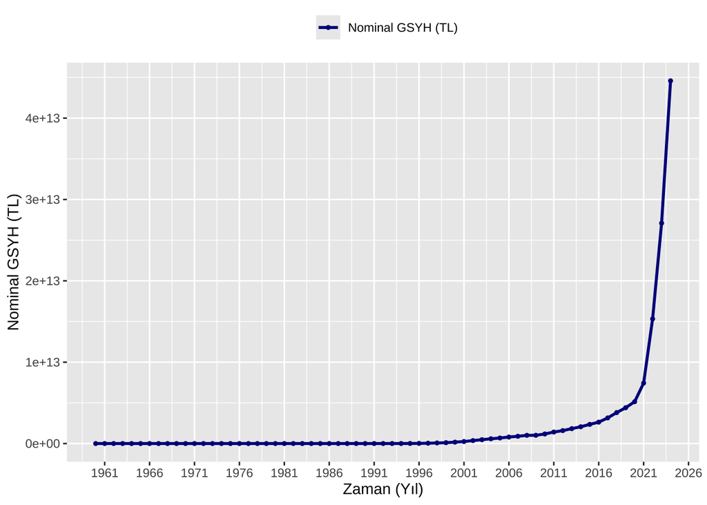

```r
# Grafik
temp <- data
variable <- "GDP"
variable.name <- "Nominal GSYH (TL)"

ggplot(temp) +
    geom_line(aes(x = Date, y = temp[ , variable], colour = "Variable"), linetype = 1, size = 1) +
    geom_point(aes(x = Date, y = temp[ , variable], colour = "Variable"), size = 1) +
    xlab("Zaman (Yıl)") + ylab(variable.name) +
    # labs(title = "Başlık") + ## Grafik için isterseniz başlık eklenebilir.
    scale_x_date(date_breaks = "5 year", date_labels = "%Y") +
    scale_colour_manual(name = "", labels = c(variable.name), values = c("Variable" = "darkblue")) +
    theme_grey() +
    theme(legend.position = "top")
```

## 2.2 R Paketleri Verisi

- Bazı **R paketlerinde mevcut olan veriyi** direkt olarak yüklemeye çalışalım.
- İndirdiğiniz ve daha sonra yüklediğiniz R paketleri içerisindeki veriyi genellikle çok basit birkaç fonksiyonu kullanarak R’ın içine yükleyebilirsiniz.
  - R paketi içinden veri yüklemek genellikle verinin paket içindeki ismi ve `data` fonksiyonu kullanılarak yapılır. Örneğin: `fpp2` Paketi Verisi bölümünde, paket içindeki verinin ismi ve `data` fonksiyonu kullanılarak istenilen veri yüklenmiştir.
  - Bazı R paketlerinde ise verinin belli bir ismi olmadığından, yüklenmek istenilen veri paket içinden belirli fonksiyonlar kullanılarak seçilmelidir. Örneğin: `tsdl` Paketi Verisi bölümünde, paket içindeki verinin ismi belli olmadığından farklı birkaç fonksiyon kullanılarak istenilen veri yüklenmiştir.
- R paketlerinin içinde olan verileri toplu olarak görmek için [Vincent Arel-Bundock](http://arelbundock.com/) tarafından hazırlanan [web sitesini](https://vincentarelbundock.github.io/Rdatasets/articles/data.html) inceleyebilirsiniz.

### 2.2.1 `fpp2` Paketi Verisi

- R paketlerinde mevcut olan veriyi, verinin ismini kullanarak yüklemek için 1 fonksiyon kullanacağız: `data`.
  - `data` fonksiyonu ile istediğimiz veriyi verinin R paketi içindeki ismini kullanarak direkt olarak R’ın içine yükleyebiliriz.
- Örnek olması açısından [`fpp2`](https://cran.r-project.org/package=fpp2) R paketinden “Avustralya Elektrik Üretimi (milyar kWh)” verisini yükleyelim.
  - `fpp2` R paketinden yüklemek istediğimiz verinin ismi `qauselec`’tir.
- Daha sonra yüklediğimiz bu veriyi temizleyelim ve düzenleyelim.
- Son olarak temizlenmiş ve düzenlemiş veriyi grafiğe dökelim.

```r
data(qauselec) ## Datayı yüklüyoruz.
data <- qauselec ## Yüklediğimiz datayı "data" ismi ile kaydediyoruz.
head(data, 20) ## Datanın yapısını inceleyelim. İlk 20 gözlemin gösterilmesini istedik.
```

```
#>       Qtr1  Qtr2  Qtr3  Qtr4
#> 1956 3.923 4.436 4.806 4.418
#> 1957 4.339 4.811 5.259 4.735
#> 1958 4.608 5.196 5.609 4.977
#> 1959 4.883 5.744 6.035 5.514
#> 1960 5.387 6.211 6.659 5.983
```

```r
data <- data.frame(Date = as.Date(date_decimal(as.numeric(time(data)))), Elec.Prod = as.matrix(data), stringsAsFactors = FALSE) ## Yüklediğimiz data time series formatında olduğu için bu datayı data.frame formatına çeviriyoruz.
data ## Datanın yapısını inceleyelim.
```

| Date | Elec.Prod |
| --- | --- |
| 1956-01-01 | 3.923 |
| 1956-04-01 | 4.436 |
| 1956-07-02 | 4.806 |
| 1956-10-01 | 4.418 |
| 1957-01-01 | 4.339 |
| 1957-04-02 | 4.811 |
| 1957-07-02 | 5.259 |
| 1957-10-01 | 4.735 |
| 1958-01-01 | 4.608 |
| 1958-04-02 | 5.196 |

[output cut: 208 more lines]

```r
data <- data[order(data$Date, decreasing = FALSE, na.last = FALSE), ] ## Datayı tarihe göre sıralıyoruz.
rownames(data) <- 1:nrow(data) ## Satır sayılarını sıralıyoruz.
data ## Datanın yapısını inceleyelim.
```

|  | Date | Elec.Prod |
| --- | --- | --- |
| 1 | 1956-01-01 | 3.923 |
| 2 | 1956-04-01 | 4.436 |
| 3 | 1956-07-02 | 4.806 |
| 4 | 1956-10-01 | 4.418 |
| 5 | 1957-01-01 | 4.339 |
| 6 | 1957-04-02 | 4.811 |
| 7 | 1957-07-02 | 5.259 |
| 8 | 1957-10-01 | 4.735 |
| 9 | 1958-01-01 | 4.608 |
| 10 | 1958-04-02 | 5.196 |

[output cut: 208 more lines]

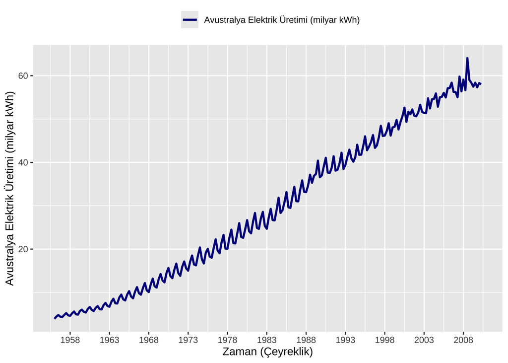

```r
# Grafik
temp <- data
variable <- "Elec.Prod"
variable.name <- "Avustralya Elektrik Üretimi (milyar kWh)"

ggplot(temp) +
    geom_line(aes(x = Date, y = temp[ , variable], colour = "Variable"), linetype = 1, size = 1) +
    xlab("Zaman (Çeyreklik)") + ylab(variable.name) +
    # labs(title = "Başlık") + ## Grafik için isterseniz başlık eklenebilir.
    scale_x_date(date_breaks = "5 year", date_labels = "%Y") +
    scale_colour_manual(name = "", labels = c(variable.name), values = c("Variable" = "darkblue")) +
    theme_grey() +
    theme(legend.position = "top")
```

### 2.2.2 `tsdl` Paketi Verisi

- R paketlerinde mevcut olan veriyi, verinin ismini bilmeden yüklemek için 1 fonksiyon kullanacağız: `subset`
  - `subset` fonksiyonu ile istediğimiz veriyi verinin R paketi içindeki ismini kullanmadan direkt olarak R’ın içine yükleyebiliriz.
- Örnek olması açısından [`tsdl`](https://pkg.yangzhuoranyang.com/tsdl/articles/tsdl.html) R paketinden, veriyi adım adım ilerleyerek önce belirleyelim ve sonra yükleyelim.
- `tsdl` R paketindeki tüm verilerin zaman serisi formatında, yani `ts()`, olduğu unutulmamalıdır.
- Son olarak yüklediğimiz bu veriyi grafiğe dökelim.

```r
Load.Install("tsdl")
tsdl ## tsdl paketinin içinde bulunan verilerin konulara ve frekansa göre kategorisi. Daha sonra bu obje datanın yüklenmesi için kullanılacaktır.
```

```
#> Time Series Data Library: 648 time series
#>
#>                        Frequency
#> Subject                 0.1 0.25   1   4   5   6  12
#>   Agriculture             0    0  37   0   0   0   3
#>   Chemistry               0    0   8   0   0   0   0
#>   Computing               0    0   6   0   0   0   0
#>   Crime                   0    0   1   0   0   0   2
#>   Demography              1    0   9   2   0   0   3
#>   Ecology                 0    0  23   0   0   0   0
#>   Finance                 0    0  23   5   0   0  20
#>   Health                  0    0   8   0   0   0   6
#>   Hydrology               0    0  42   0   0   0  78
#>   Industry                0    0   9   0   0   0   2
#>   Labour market           0    0   3   4   0   0  17
#>   Macroeconomic           0    0  18  33   0   0   5
#>   Meteorology             0    0  18   0   0   0  17
#>   Microeconomic           0    0  27   1   0   0   7
#>   Miscellaneous           0    0   4   0   1   1   3
#>   Physics                 0    0  12   0   0   0   4
#>   Production              0    0   4  14   0   0  28
#>   Sales                   0    0  10   3   0   0  24
#>   Sport                   0    1   1   0   0   0   0
#>   Transport and tourism   0    0   1   1   0   0  12
#>   Tree-rings              0    0  34   0   0   0   1
#>   Utilities               0    0   2   1   0   0   8
#>   Total                   1    1 300  64   1   1 240
#>                        Frequency
#> Subject                  13  52 365 Total
#>   Agriculture             0   0   0    40
#>   Chemistry               0   0   0     8
#>   Computing               0   0   0     6
#>   Crime                   1   0   0     4
#>   Demography              0   0   2    17
#>   Ecology                 0   0   0    23
#>   Finance                 0   2   1    51
#>   Health                  0   1   0    15
#>   Hydrology               1   0   6   127
#>   Industry                0   1   0    12
#>   Labour market           0   0   0    24
#>   Macroeconomic           0   0   0    56
#>   Meteorology             0   0  12    47
#>   Microeconomic           0   1   0    36
#>   Miscellaneous           0   1   0    10
#>   Physics                 0   0   0    16
#>   Production              1   1   0    48
#>   Sales                   0   9   0    46
#>   Sport                   0   0   0     2
#>   Transport and tourism   0   0   0    14
#>   Tree-rings              0   0   0    35
#>   Utilities               0   0   0    11
#>   Total                   3  16  21   648
```

```r
datatable(meta_tsdl, filter = "top", options = list(pageLength = 5, autoWidth = TRUE)) ## tsdl paketinin içinde bulunan verilerin metadatası (bilgisi). Bu tabloya bakarak istediğimız datayı sıra numarasını kullanarak ya da diğer başka fonksiyonları kullanarak seçebiliriz.
```

|  | source | description | frequency | start | subject |
| --- | --- | --- | --- | --- | --- |
| 1 | Abraham &amp; Ledolter (1983) | ['Quarterly Iowa nonfarm income (1948 – 1979)'] | 4 | 1948 | Macroeconomic |
| 2 | Abraham &amp; Ledolter (1983) | ['Monthly demand repair parts large/heavy equip. Iowa 1972 – 1979'] | 12 | 1972 | Industry |
| 3 | Abraham &amp; Ledolter (1983) | ['Montly av. residential gas usage Iowa (cubic feet)*100 –71 – –79'] | 12 | 1971 | Utilities |
| 4 | Abraham &amp; Ledolter (1983) | ['Monthly gasoline demand Ontario gallon millions 1960 – 1975'] | 12 | 1960 | Sales |
| 5 | Abraham &amp; Ledolter (1983) | ['Monthly % changes in Canadian wages and salaries –67 – –75'] | 12 | 1967 | Macroeconomic |
| 6 | Abraham &amp; Ledolter (1983) | ['Monthly sales of U.S. houses (thousands) 1965 – 1975'] | 12 | 1965 | Sales |
| 7 | Abraham &amp; Ledolter (1983) | ['Quarterly growth rates of Iowa nonfarm income (1948 – 1979)'] | 4 | 1948 | Macroeconomic |
| 8 | Abraham &amp; Ledolter (1983) | ['Monthly Av. residential electricity usage Iowa city 1971 – 1979'] | 12 | 1971 | Utilities |
| 9 | Abraham &amp; Ledolter (1983) | ['Monthly car sales in Quebec 1960-1968'] | 12 | 1960 | Sales |
| 10 | Abraham &amp; Ledolter (1983) | ['Monthly traffic fatalities in Ontario 1960-1974'] | 12 | 1960 | Transport and tourism |

[output cut: 638 more lines]

```r
# İstenilen datanın yüklenmesi.
## İstediğimiz data 134. sırada bulunan: Monthly Australian imports from Japan: thousands of dollars. Jul 65 – Oct 93.
data <- subset(tsdl, description = "Monthly Australian imports from Japan")[[1]] ## Alternatif olarak datayı bu şekilde de yükleyebiliriz.
data <- tsdl[[134]] ## Sıra numarası kullanarak datayı yüklüyoruz. Bu datanın zaman serisi objesi olduğuna dikkat edin.
head(data, 30) ## Datanın yapısını inceleyelim.
```

```
#>        Jan   Feb   Mar   Apr   May   Jun   Jul   Aug
#> 1965                                     27418 30592
#> 1966 25333 17004 20249 21384 19565 21253 23041 23026
#> 1967 29008 18387 26340 21437 27105 30316 22101 34180
#>        Sep   Oct   Nov   Dec
#> 1965 23910 25509 27003 20943
#> 1966 23860 22295 27286 23928
#> 1967 32133 29867 27710 25342
```

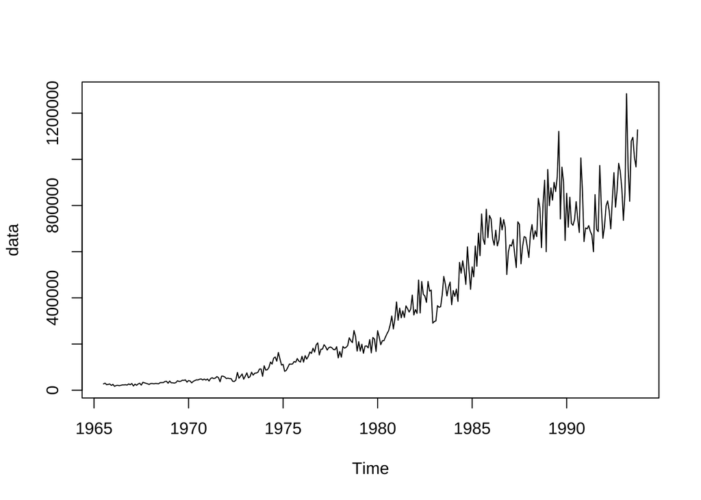

```r
# Grafik
## Elimizdeki veri zaman serisi objesi olduğu için plot fonksiyonunu kullanarak direkt olarak grafiğe dökebiliriz.
plot(data)
```

## 2.3 Excel Verisi

- Excel dosyasından direkt olarak veri yüklemeye çalışalım.
- Excel dosyasından veri yüklemek için 1 fonksiyon kullanacağız: `read_excel`.
  - `read_excel` fonksiyonu ile veriyi direkt olarak R’ın içine yükleyebiliriz.
- Örnek olması açısından “İstanbul’a Verilen Temiz Su Miktarları” verisini yükleyelim.
  - İlgili veri: [`clean-water.xlsx`](https://akademiekonometri.netlify.app/repo/akek/r/courses/zaman-serileri-analizi/Hafta_1/clean-water.xlsx)
- Daha sonra yüklediğimiz bu veriyi temizleyelim ve düzenleyelim.
- Son olarak temizlenmiş ve düzenlemiş veriyi grafiğe dökelim.

```r
file.path <- "clean-water.xlsx" ## Data dosyasının ismi ve uzantısı.

# Ham datanın yüklenmesi
data <- read_excel(path = file.path, sheet = 3, range = cell_limits(c(1, 1), c(NA, NA)), col_names = TRUE, col_types = "text") ## Yüklediğimiz datayı tibble formatında kaydediyoruz.
data <- as.data.frame(data, stringsAsFactors = FALSE) ## Datayı data.frame formatına çeviriyoruz.
data ## Datanın yapısını inceleyelim.
```

| Ay | 2009 | 2010 | 2011 | 2012 | 2013 | 2014 | 2015 | 2016 | 2017 | 2018 | 2019 |
| --- | --- | --- | --- | --- | --- | --- | --- | --- | --- | --- | --- |
| Ocak | 55926 | 60626 | 65178 | 67137 | 71538 | 74528 | 77053 | 80206 | 81757 | 84212 | 83576 |
| Şubat | 50838 | 55607 | 59159 | 63613 | 64379 | 66844 | 67912 | 74114 | 73515 | 75692 | 74797 |
| Mart | 57261 | 60690 | 65895 | 67727 | 71663 | 73786 | 75459 | 79147 | 81215 | 84274 | 84666 |
| Nisan | 56034 | 60060 | 63179 | 66769 | 70859 | 72909 | 74177 | 80340 | 80663 | 84239 | 84968 |
| Mayıs | 62878 | 68131 | 69283 | 71704 | 80496 | 79584 | 82905 | 84951 | 87441 | 90369 | 93692 |
| Haziran | 65211 | 65795 | 72126 | 77507 | 79433 | 80020 | 82472 | 88033 | 87008 | 90831 | 93135 |
| Temmuz | 66197 | 68314 | 76919 | 83574 | 84224 | 84905 | 88453 | 88076 | 93177 | 95090 | 96028 |
| Ağustos | 66583 | 75594 | 75957 | 80098 | 82987 | 83262 | 89859 | 91773 | 91794 | 93402 | 94171 |
| Eylül | 61154 | 66734 | 71906 | 76396 | 80163 | 78215 | 84083 | 84767 | 87630 | 88053 | 91987 |
| Ekim | 61555 | 66419 | 70069 | 75991 | 76077 | 77767 | 82263 | 85454 | 87114 | 86864 | 90439 |

[output cut: 2 more lines]

```r
colnames(data)[1] <- "Month" ## İlk sütun ismini değiştiriyoruz.
data$Month <- 1:12 ## İlk sütundaki hücrelere ay ismi yerine rakam veriyoruz.

# Datanın dönüştürülmesi.
data <- reshape2::melt(data, id.vars = c("Month"), variable_name = "value")

# Bazı değişiklikler.
data <- dplyr::rename(data, Year = variable)
data <- dplyr::rename(data, Clean.Water = value)
data$Year <- as.numeric(as.character(data$Year))
data$Clean.Water <- as.numeric(data$Clean.Water)
data$Date <- as.Date(paste(data$Year, data$Month, "1", sep = "-")) ## Date adlı tarihi belirten yeni bir değişken oluşturuyoruz.
data <- data[, c("Date", "Year", "Month", "Clean.Water")] ## İstediğimiz değişkenleri belirtiyoruz.
data <- data[data$Year != 2019, ] ## 2019 datasının son gözleminde bir problem olduğu için 2019 yılını siliyoruz.
data <- data[order(data$Date, decreasing = FALSE, na.last = FALSE), ] ## Datayı tarihe göre sıralıyoruz.
rownames(data) <- 1:nrow(data) ## Satır sayılarını sıralıyoruz.
data ## Datanın yapısını inceleyelim.
```

|  | Date | Year | Month | Clean.Water |
| --- | --- | --- | --- | --- |
| 1 | 2009-01-01 | 2009 | 1 | 55926 |
| 2 | 2009-02-01 | 2009 | 2 | 50838 |
| 3 | 2009-03-01 | 2009 | 3 | 57261 |
| 4 | 2009-04-01 | 2009 | 4 | 56034 |
| 5 | 2009-05-01 | 2009 | 5 | 62878 |
| 6 | 2009-06-01 | 2009 | 6 | 65211 |
| 7 | 2009-07-01 | 2009 | 7 | 66197 |
| 8 | 2009-08-01 | 2009 | 8 | 66583 |
| 9 | 2009-09-01 | 2009 | 9 | 61154 |
| 10 | 2009-10-01 | 2009 | 10 | 61555 |

[output cut: 110 more lines]

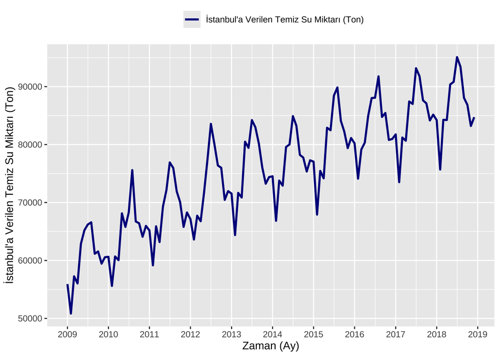

```r
# Grafik
temp <- data
variable <- "Clean.Water"
variable.name <- "İstanbul'a Verilen Temiz Su Miktarı (Ton)"

ggplot(temp) +
    geom_line(aes(x = Date, y = temp[ , variable], colour = "Variable"), linetype = 1, size = 1) +
    xlab("Zaman (Ay)") + ylab(variable.name) +
    # labs(title = "Başlık") + ## Grafik için isterseniz başlık eklenebilir.
    scale_x_date(date_breaks = "1 year", date_labels = "%Y") +
    scale_colour_manual(name = "", labels = c(variable.name), values = c("Variable" = "darkblue")) +
    theme_grey() +
    theme(legend.position = "top")
```

## 2.4 CSV Verisi

- CSV dosyasından den direkt olarak veri yüklemeye çalışalım.
- CSV dosyasından veri yüklemek için 1 fonksiyon kullanacağız: `read.csv`.
  - `read.csv` fonksiyonu ile veriyi direkt olarak R’ın içine yükleyebiliriz.
- Örnek olması açısından “İstanbul Barajlarinin Doluluk Oranları” verisini yükleyelim.
  - İlgili veri: [`dam_occupancy.csv`](https://akademiekonometri.netlify.app/repo/akek/r/courses/zaman-serileri-analizi//Hafta_1/dam_occupancy.csv)
- Daha sonra yüklediğimiz bu veriyi temizleyelim ve düzenleyelim.
- Son olarak temizlenmiş ve düzenlemiş veriyi grafiğe dökelim.

```r
file.path <- "dam_occupancy.csv" ## Data dosyasının ismi ve uzantısı.

# Ham datanın yüklenmesi
data <- read.csv(file = file.path, header = TRUE, sep = ",", dec = ".", colClasses = "character", comment.char = "", na.string = "") ## Datanın yüklenmesi.
data ## Datanın yapısını inceleyelim.
```

| DATE | GENERAL_DAM_OCCUPANCY_RATE | GENERAL_DAM_RESERVED_WATER |
| --- | --- | --- |
| 2005-01-01 | 44.62 | 388 |
| 2005-01-02 | 44.62 | 388 |
| 2005-01-03 | 44.47 | 386 |
| 2005-01-04 | 44.42 | 386 |
| 2005-01-05 | 44.35 | 385 |
| 2005-01-06 | 44.26 | 385 |
| 2005-01-07 | 44.16 | 384 |
| 2005-01-08 | 44.01 | 382 |
| 2005-01-09 | 43.85 | 381 |
| 2005-01-10 | 43.67 | 379 |

[output cut: 990 more lines]

```r
colnames(data) <- c("Date", "Occupancy.Rate", "Reserved.Water") ## Sütun isimlerinin değiştirilmesi.
data$Occupancy.Rate <- as.numeric(data$Occupancy.Rate) ## Numerik kategori olarak değiştirildi.
data$Reserved.Water <- as.numeric(data$Reserved.Water) ## Numerik kategori olarak değiştirildi.
data$Date <- as.Date(data$Date, tz = "UTC", format = "%Y-%m-%d") ## Date kategori olarak değiştirildi.
data <- data[order(data$Date, decreasing = FALSE, na.last = FALSE), ] ## Datayı tarihe göre sıralıyoruz.
rownames(data) <- 1:nrow(data) ## Satır sayılarını sıralıyoruz.
data ## Datanın yapısını inceleyelim.
```

|  | Date | Occupancy.Rate | Reserved.Water |
| --- | --- | --- | --- |
| 1 | 2005-01-01 | 44.62 | 388 |
| 2 | 2005-01-02 | 44.62 | 388 |
| 3 | 2005-01-03 | 44.47 | 386 |
| 4 | 2005-01-04 | 44.42 | 386 |
| 5 | 2005-01-05 | 44.35 | 385 |
| 6 | 2005-01-06 | 44.26 | 385 |
| 7 | 2005-01-07 | 44.16 | 384 |
| 8 | 2005-01-08 | 44.01 | 382 |
| 9 | 2005-01-09 | 43.85 | 381 |
| 10 | 2005-01-10 | 43.67 | 379 |

[output cut: 990 more lines]

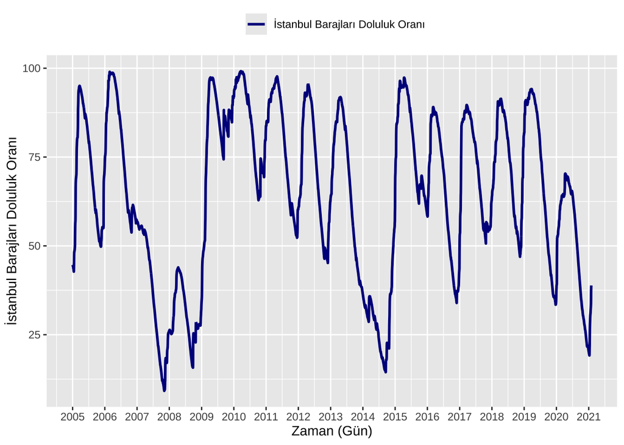

```r
# Grafik
temp <- data
variable <- "Occupancy.Rate"
variable.name <- "İstanbul Barajları Doluluk Oranı"

ggplot(temp) +
    geom_line(aes(x = Date, y = temp[ , variable], colour = "Variable"), linetype = 1, size = 1) +
    xlab("Zaman (Gün)") + ylab(variable.name) +
    # labs(title = "Başlık") + ## Grafik için isterseniz başlık eklenebilir.
    scale_x_date(date_breaks = "1 year", date_labels = "%Y") +
    scale_colour_manual(name = "", labels = c(variable.name), values = c("Variable" = "darkblue")) +
    theme_grey() +
    theme(legend.position = "top")
```

## 2.5 Yahoo Finance Verisi

- [Yahoo Finance](https://finance.yahoo.com/)’ten direkt olarak `quantmod` R paketini kullanarak veri indirip yüklemeye çalışalım.
- Yahoo Finance’ten veri indirip yüklemek için 1 fonksiyon kullanacağız: `loadSymbols`.
  - `loadSymbols` fonksiyonu ile istediğimiz veriyi direkt olarak R’ın içine yükleyebiliriz.
- Örnek olması açısından “Google Hisse Senedi Fiyatı” verisini indirip yükleyelim.
- Daha sonra indirip yüklediğimiz bu veriyi temizleyelim ve düzenleyelim.
- Son olarak temizlenmiş ve düzenlemiş veriyi grafiğe dökelim.

```r
loadSymbols(Symbols = "GOOG", periodicity = "daily", return.class = "data.frame") ## Yahoo Finance uzerinden buldugumuz sembolu (GOOG) kullanarak ve datanın frekansını seçerek datayı indirip yükleyebiliriz. İndirdiğimiz datanın ismi sembol ismi ile aynı olacaktır.
```

```
#> [1] "GOOG"
```

```r
GOOG ## Datanın yapısını inceleyelim.
```

|  | GOOG.Open | GOOG.High | GOOG.Low | GOOG.Close | GOOG.Volume | GOOG.Adjusted |
| --- | --- | --- | --- | --- | --- | --- |
| 2007-01-03 | 11.6064959 | 11.8720007 | 11.4847031 | 11.6460981 | 309415434 | 11.5594006 |
| 2007-01-04 | 11.6812162 | 12.0535698 | 11.6650267 | 12.0363846 | 316686586 | 11.9467821 |
| 2007-01-05 | 12.0174561 | 12.1419888 | 11.9081154 | 12.1342678 | 275914333 | 12.0439367 |
| 2007-01-08 | 12.1467209 | 12.2010183 | 12.0099840 | 12.0443554 | 190888826 | 11.9546928 |
| 2007-01-09 | 12.0909300 | 12.1606693 | 11.9850769 | 12.0921764 | 216062832 | 12.0021591 |
| 2007-01-10 | 12.0655251 | 12.2926741 | 12.0059986 | 12.1908064 | 239634856 | 12.1000538 |
| 2007-01-11 | 12.3835831 | 12.4969091 | 12.3581791 | 12.4463482 | 289408724 | 12.3536940 |
| 2007-01-12 | 12.5028858 | 12.5778551 | 12.4533224 | 12.5778551 | 179618741 | 12.4842215 |
| 2007-01-16 | 12.6413670 | 12.7771082 | 12.5355139 | 12.5599222 | 303890804 | 12.4664211 |
| 2007-01-17 | 12.5377550 | 12.6468468 | 12.3133469 | 12.3855762 | 268968395 | 12.2933741 |

[output cut: 990 more lines]

```r
data <- data.frame(Date = gsub("\\.", "-", gsub("X", "", rownames(GOOG))), Google = GOOG$GOOG.Close, stringsAsFactors = FALSE) ## Kapanış fiyatları seçiliyor ve sütun ismi olarak Google veriliyor.
data$Date <- as.Date(data$Date) ## Date kategori olarak değiştiriliyor.
data <- data[order(data$Date, decreasing = FALSE, na.last = FALSE), ] ## Datayı tarihe göre sıralıyoruz.
rownames(data) <- 1:nrow(data) ## Satır sayılarını sıralıyoruz.
data ## Datanın yapısını inceleyelim.
```

|  | Date | Google |
| --- | --- | --- |
| 1 | 2007-01-03 | 11.6460981 |
| 2 | 2007-01-04 | 12.0363846 |
| 3 | 2007-01-05 | 12.1342678 |
| 4 | 2007-01-08 | 12.0443554 |
| 5 | 2007-01-09 | 12.0921764 |
| 6 | 2007-01-10 | 12.1908064 |
| 7 | 2007-01-11 | 12.4463482 |
| 8 | 2007-01-12 | 12.5778551 |
| 9 | 2007-01-16 | 12.5599222 |
| 10 | 2007-01-17 | 12.3855762 |

[output cut: 990 more lines]

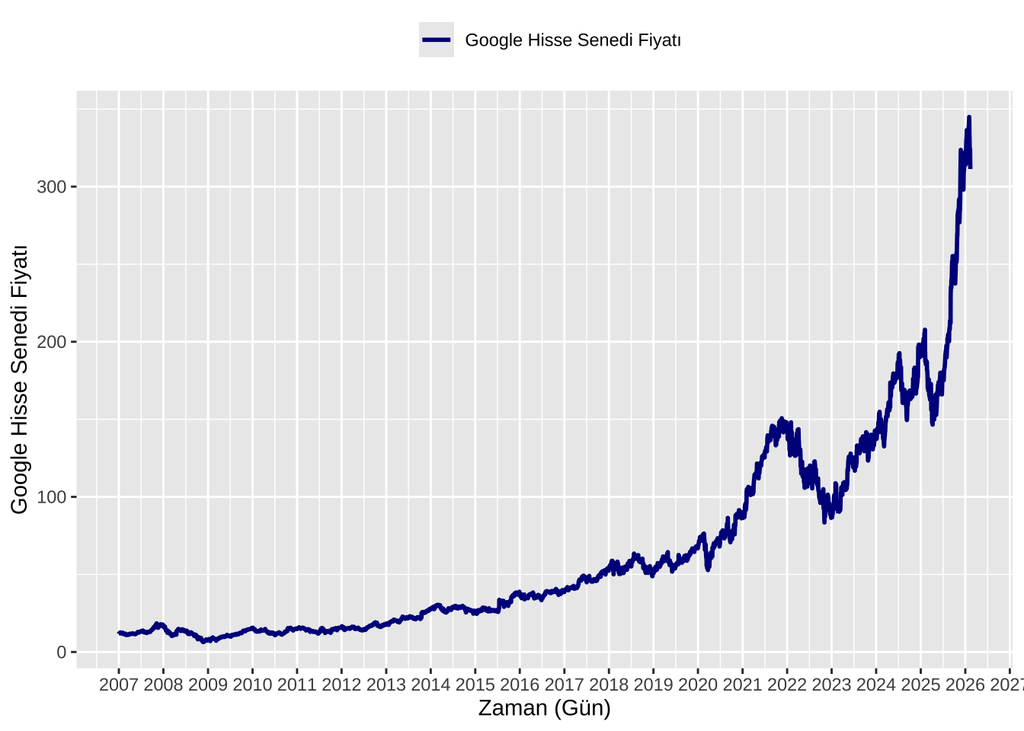

```r
# Grafik
temp <- data
variable <- "Google"
variable.name <- "Google Hisse Senedi Fiyatı"

ggplot(temp) +
    geom_line(aes(x = Date, y = temp[ , variable], colour = "Variable"), linetype = 1, size = 1) +
    xlab("Zaman (Gün)") + ylab(variable.name) +
    # labs(title = "Başlık") + ## Grafik için isterseniz başlık eklenebilir.
    scale_x_date(date_breaks = "1 year", date_labels = "%Y") +
    scale_colour_manual(name = "", labels = c(variable.name), values = c("Variable" = "darkblue")) +
    theme_grey() +
    theme(legend.position = "top")
```

# 3 Verinin Hazırlanması

- Bu bölümde **zaman serileri verisinin hazırlanması için uygulanabilecek teknikler** farklı kaynaklardan veriler kullanılarak gösterilecektir.

## 3.1 Enflasyon Ayarlaması

- Örnek olması açısından World Bank’ten “Türkiye için Nominal Gayri Safi Yurtiçi Hasıla” verisini TL cinsinden ve “Türkiye için Gayri Safi Yurtiçi Hasıla Deflatörü (2009 Baz Yılı)” verisini beraber indirip yükleyelim.
- Daha sonra indirip yüklediğimiz bu veriyi temizleyelim ve düzenleyelim.
- Daha sonra temizlenmiş ve düzenlenmiş verinin **enflasyon ayarlamasını** yapalım.
- Son olarak enflasyon ayarlaması yapılmış veriyi grafiğe dökelim.

```r
WDIsearch(string = "gdp.*current.*LCU", field = "name", short = TRUE, cache = NULL) ## Olası seriler ve kodları. Biz "NY.GDP.MKTP.CN" GDP (current LCU) datasını kullanacağız.
```

|  | indicator | name |
| --- | --- | --- |
| 13538 | NV.SRV.DISC.CN | Discrepancy in GDP, value added (current LCU) |
| 13758 | NY.GDP.DISC.CN | Discrepancy in expenditure estimate of GDP (current LCU) |
| 13770 | NY.GDP.MKTP.CN | GDP (current LCU) |
| 13771 | NY.GDP.MKTP.CN.AD | GDP: linked series (current LCU) |
| 13788 | NY.GDP.PCAP.CN | GDP per capita (current LCU) |
| 13895 | NYGDPMKTPSACN | GDP,current LCU,millions,seas. adj., |

```r
WDIsearch(string = "gdp.*deflator", field = "name", short = TRUE, cache = NULL) ## Olası seriler ve kodları. Biz "NY.GDP.DEFL.ZS" GDP deflator (base year varies by country) datasını kullanacağız. 2009 baz yılı kullanılıyor.
```

|  | indicator | name |
| --- | --- | --- |
| 13751 | NY.GDP.DEFL.87.ZG | Inflation, GDP deflator (annual %) |
| 13752 | NY.GDP.DEFL.KD.ZG | Inflation, GDP deflator (annual %) |
| 13753 | NY.GDP.DEFL.KD.ZG.AD | Inflation, GDP deflator: linked series (annual %) |
| 13754 | NY.GDP.DEFL.ZS | GDP deflator (base year varies by country) |
| 13755 | NY.GDP.DEFL.ZS.87 | GDP deflator (1987 = 100) |
| 13756 | NY.GDP.DEFL.ZS.AD | GDP deflator: linked series (base year varies by country) |
| 13769 | NY.GDP.MKTP.CD.XD | GDP deflator, index (2000=100; US$ series) |
| 13772 | NY.GDP.MKTP.CN.XD | GDP deflator, period average (LCU index 2000=100) |
| 13773 | NY.GDP.MKTP.IN | GDP Deflator |
| 13783 | NY.GDP.MKTP.XD | GDP deflator (1987=100,Index) |

[output cut: 1 more lines]

```r
data <- WDI(country = c("TR"), indicator = c("NY.GDP.MKTP.CN", "NY.GDP.DEFL.ZS"), start = 1960, end = 2026, extra = FALSE) ## Bir önceki kodda belirlediğimiz indikatör isimlerini ve ülke kısaltmasını kullanıyoruz. Datanın başlangıç ve bitiş tarihlerini de ayrı ayrı belirtiyoruz.
data ## Datanın yapısını inceleyelim.
```

| country | iso2c | iso3c | year | NY.GDP.MKTP.CN | NY.GDP.DEFL.ZS |
| --- | --- | --- | --- | --- | --- |
| Turkiye | TR | TUR | 1960 | 68100 | 0.000055281863 |
| Turkiye | TR | TUR | 1961 | 71900 | 0.000057699560 |
| Turkiye | TR | TUR | 1962 | 80300 | 0.000061039752 |
| Turkiye | TR | TUR | 1963 | 93200 | 0.000064956487 |
| Turkiye | TR | TUR | 1964 | 100600 | 0.000066484547 |
| Turkiye | TR | TUR | 1965 | 107700 | 0.000069222284 |
| Turkiye | TR | TUR | 1966 | 126900 | 0.000073339342 |
| Turkiye | TR | TUR | 1967 | 140800 | 0.000077695619 |
| Turkiye | TR | TUR | 1968 | 157500 | 0.000081394052 |
| Turkiye | TR | TUR | 1969 | 175200 | 0.000086990965 |

[output cut: 55 more lines]

```r
data <- data[, c("year", "NY.GDP.MKTP.CN", "NY.GDP.DEFL.ZS")] ## İstediğimiz değişkenleri belirtiyoruz.
colnames(data) <- c("Year", "GDP", "GDP.Deflator") ## Değişkenlere yeni isimler veriyoruz.
data$Date <- as.Date(paste(data$Year, "1", "1", sep = "-")) ## Date adlı yeni bir değişken oluşturuyoruz.
data <- data[, c("Date", "Year", "GDP", "GDP.Deflator")] ## Değişkenleri sütun olarak sıralıyoruz.
data <- data[order(data$Date, data$Year, decreasing = FALSE, na.last = FALSE), ] ## Datayı tarihe göre sıralıyoruz.
rownames(data) <- 1:nrow(data) ## Satır sayılarını sıralıyoruz.
data ## Datanın yapısını inceleyelim.
```

|  | Date | Year | GDP | GDP.Deflator |
| --- | --- | --- | --- | --- |
| 1 | 1960-01-01 | 1960 | 68100 | 0.000055281863 |
| 2 | 1961-01-01 | 1961 | 71900 | 0.000057699560 |
| 3 | 1962-01-01 | 1962 | 80300 | 0.000061039752 |
| 4 | 1963-01-01 | 1963 | 93200 | 0.000064956487 |
| 5 | 1964-01-01 | 1964 | 100600 | 0.000066484547 |
| 6 | 1965-01-01 | 1965 | 107700 | 0.000069222284 |
| 7 | 1966-01-01 | 1966 | 126900 | 0.000073339342 |
| 8 | 1967-01-01 | 1967 | 140800 | 0.000077695619 |
| 9 | 1968-01-01 | 1968 | 157500 | 0.000081394052 |
| 10 | 1969-01-01 | 1969 | 175200 | 0.000086990965 |

[output cut: 55 more lines]

```r
# Enflasyon ayarlaması.
data[data$GDP.Deflator == 100, "Year"] ## Datanin baz yılı belirleniyor. 2009 yılı.
```

```
#> [1] 2009
```

```r
data$R.GDP <- (data$GDP / data$GDP.Deflator) * 100 ## Enflasyon ayarlaması yapılıyor.
data ## Datanın yapısını inceleyelim.
```

|  | Date | Year | GDP | GDP.Deflator | R.GDP |
| --- | --- | --- | --- | --- | --- |
| 1 | 1960-01-01 | 1960 | 68100 | 0.000055281863 | 123186875433 |
| 2 | 1961-01-01 | 1961 | 71900 | 0.000057699560 | 124611001187 |
| 3 | 1962-01-01 | 1962 | 80300 | 0.000061039752 | 131553614123 |
| 4 | 1963-01-01 | 1963 | 93200 | 0.000064956487 | 143480666745 |
| 5 | 1964-01-01 | 1964 | 100600 | 0.000066484547 | 151313357837 |
| 6 | 1965-01-01 | 1965 | 107700 | 0.000069222284 | 155585735199 |
| 7 | 1966-01-01 | 1966 | 126900 | 0.000073339342 | 173031275908 |
| 8 | 1967-01-01 | 1967 | 140800 | 0.000077695619 | 181219998765 |
| 9 | 1968-01-01 | 1968 | 157500 | 0.000081394052 | 193503083052 |
| 10 | 1969-01-01 | 1969 | 175200 | 0.000086990965 | 201400225652 |

[output cut: 55 more lines]

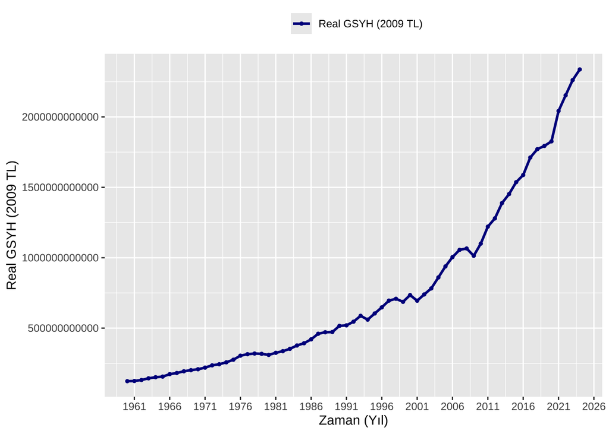

```r
# Grafik
temp <- data
variable <- "R.GDP"
variable.name <- "Real GSYH (2009 TL)"

ggplot(temp) +
    geom_line(aes(x = Date, y = temp[ , variable], colour = "Variable"), linetype = 1, size = 1) +
    geom_point(aes(x = Date, y = temp[ , variable], colour = "Variable"), size = 1) +
    xlab("Zaman (Yıl)") + ylab(variable.name) +
    # labs(title = "Başlık") + ## Grafik için isterseniz başlık eklenebilir.
    scale_x_date(date_breaks = "5 year", date_labels = "%Y") +
    scale_colour_manual(name = "", labels = c(variable.name), values = c("Variable" = "darkblue")) +
    theme_grey() +
    theme(legend.position = "top")
```

## 3.2 Nüfus Ayarlaması

- Örnek olması açısından World Bank’ten “Türkiye için Reel Gayri Safi Yurtiçi Hasıla (2009 Baz Yılı)” verisini TL cinsinden ve “Türkiye için Nüfus” verisini beraber indirip yükleyelim.
- Daha sonra indirip yüklediğimiz bu veriyi temizleyelim ve düzenleyelim.
- Daha sonra temizlenmiş ve düzenlenmiş verinin **nüfus ayarlamasını** yapalım.
- Son olarak nüfus ayarlaması yapılmış veriyi grafiğe dökelim.

```r
WDIsearch(string = "gdp.*constant.*LCU", field = "name", short = TRUE, cache = NULL) ## Olası seriler ve kodları. Biz "NY.GDP.MKTP.KN" GDP (constant LCU) datasını kullanacağız. 2009 baz yılı kullanılıyor.
```

|  | indicator | name |
| --- | --- | --- |
| 13539 | NV.SRV.DISC.KN | Discrepancy in GDP, value added (constant LCU) |
| 13759 | NY.GDP.DISC.KN | Discrepancy in expenditure estimate of GDP (constant LCU) |
| 13765 | NY.GDP.FCST.KN.87 | GDP at factor cost (constant 1987 LCU) |
| 13777 | NY.GDP.MKTP.KN | GDP (constant LCU) |
| 13778 | NY.GDP.MKTP.KN.87 | GDP at market prices (constant 1987 LCU) |
| 13791 | NY.GDP.PCAP.KN | GDP per capita (constant LCU) |
| 13897 | NYGDPMKTPSAKN | GDP,constant 2010 LCU,millions,seas. adj., |

```r
WDIsearch(string = "SP.POP.TOTL", field = "name", short = TRUE, cache = NULL) ## Olası seriler ve kodları. Biz "SP.POP.TOTL" Total Population datasını kullanacağız.
```

|  | indicator | name |
| --- | --- | --- |
| 22274 | SP.POP.TOTL.ICP | SP.POP.TOTL.ICP:Population |
| 22275 | SP.POP.TOTL.ICP.ZS | SP.POP.TOTL.ICP.ZS:Population shares (World=100) |

```r
data <- WDI(country = c("TR"), indicator = c("NY.GDP.MKTP.KN", "SP.POP.TOTL"), start = 1960, end = 2026, extra = FALSE) ## Bir önceki kodda belirlediğimiz indikatör isimlerini ve ülke kısaltmasını kullanıyoruz. Datanın başlangıç ve bitiş tarihlerini de ayrı ayrı belirtiyoruz.
data ## Datanın yapısını inceleyelim.
```

| country | iso2c | iso3c | year | NY.GDP.MKTP.KN | SP.POP.TOTL |
| --- | --- | --- | --- | --- | --- |
| Turkiye | TR | TUR | 1960 | 123186875433 | 28329898 |
| Turkiye | TR | TUR | 1961 | 124611001187 | 29119238 |
| Turkiye | TR | TUR | 1962 | 131553614123 | 29916147 |
| Turkiye | TR | TUR | 1963 | 143480666745 | 30726841 |
| Turkiye | TR | TUR | 1964 | 151313357837 | 31543072 |
| Turkiye | TR | TUR | 1965 | 155585735199 | 32345220 |
| Turkiye | TR | TUR | 1966 | 173031275908 | 33177672 |
| Turkiye | TR | TUR | 1967 | 181219998765 | 34050421 |
| Turkiye | TR | TUR | 1968 | 193503083052 | 34921684 |
| Turkiye | TR | TUR | 1969 | 201400225652 | 35787774 |

[output cut: 55 more lines]

```r
data <- data[, c("year", "NY.GDP.MKTP.KN", "SP.POP.TOTL")] ## İstediğimiz değişkenleri belirtiyoruz.
colnames(data) <- c("Year", "R.GDP", "Population") ## Değişkenlere yeni isimler veriyoruz.
data$Date <- as.Date(paste(data$Year, "1", "1", sep = "-")) ## Date adlı yeni bir değişken oluşturuyoruz.
data <- data[, c("Date", "Year", "R.GDP", "Population")] ## Değişkenleri sütun olarak sıralıyoruz.
data <- data[order(data$Date, data$Year, decreasing = FALSE, na.last = FALSE), ] ## Datayı tarihe göre sıralıyoruz.
rownames(data) <- 1:nrow(data) ## Satır sayılarını sıralıyoruz.
data ## Datanın yapısını inceleyelim.
```

|  | Date | Year | R.GDP | Population |
| --- | --- | --- | --- | --- |
| 1 | 1960-01-01 | 1960 | 123186875433 | 28329898 |
| 2 | 1961-01-01 | 1961 | 124611001187 | 29119238 |
| 3 | 1962-01-01 | 1962 | 131553614123 | 29916147 |
| 4 | 1963-01-01 | 1963 | 143480666745 | 30726841 |
| 5 | 1964-01-01 | 1964 | 151313357837 | 31543072 |
| 6 | 1965-01-01 | 1965 | 155585735199 | 32345220 |
| 7 | 1966-01-01 | 1966 | 173031275908 | 33177672 |
| 8 | 1967-01-01 | 1967 | 181219998765 | 34050421 |
| 9 | 1968-01-01 | 1968 | 193503083052 | 34921684 |
| 10 | 1969-01-01 | 1969 | 201400225652 | 35787774 |

[output cut: 55 more lines]

```r
# Nüfus ayarlaması.
data$R.GDP.PCAP <- data$R.GDP / data$Population ## Nüfus ayarlaması yapılıyor.
data ## Datanın yapısını inceleyelim.
```

|  | Date | Year | R.GDP | Population | R.GDP.PCAP |
| --- | --- | --- | --- | --- | --- |
| 1 | 1960-01-01 | 1960 | 123186875433 | 28329898 | 4348.2993 |
| 2 | 1961-01-01 | 1961 | 124611001187 | 29119238 | 4279.3359 |
| 3 | 1962-01-01 | 1962 | 131553614123 | 29916147 | 4397.4117 |
| 4 | 1963-01-01 | 1963 | 143480666745 | 30726841 | 4669.5548 |
| 5 | 1964-01-01 | 1964 | 151313357837 | 31543072 | 4797.0394 |
| 6 | 1965-01-01 | 1965 | 155585735199 | 32345220 | 4810.1616 |
| 7 | 1966-01-01 | 1966 | 173031275908 | 33177672 | 5215.2929 |
| 8 | 1967-01-01 | 1967 | 181219998765 | 34050421 | 5322.1074 |
| 9 | 1968-01-01 | 1968 | 193503083052 | 34921684 | 5541.0582 |
| 10 | 1969-01-01 | 1969 | 201400225652 | 35787774 | 5627.6265 |

[output cut: 55 more lines]

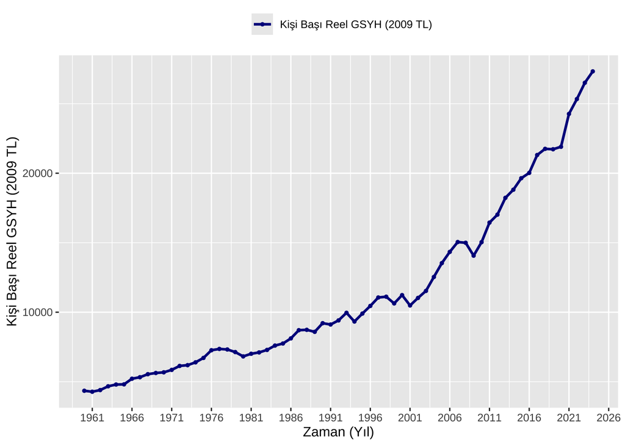

```r
# Grafik
temp <- data
variable <- "R.GDP.PCAP"
variable.name <- "Kişi Başı Reel GSYH (2009 TL)"

ggplot(temp) +
    geom_line(aes(x = Date, y = temp[ , variable], colour = "Variable"), linetype = 1, size = 1) +
    geom_point(aes(x = Date, y = temp[ , variable], colour = "Variable"), size = 1) +
    xlab("Zaman (Yıl)") + ylab(variable.name) +
    # labs(title = "Başlık") + ## Grafik için isterseniz başlık eklenebilir.
    scale_x_date(date_breaks = "5 year", date_labels = "%Y") +
    scale_colour_manual(name = "", labels = c(variable.name), values = c("Variable" = "darkblue")) +
    theme_grey() +
    theme(legend.position = "top")
```